# projekt_rpism

Kamil Kućma

18 01 2022

**1.1** Z wykorzystaniem funkcji sample() zasymuluj rzut kostką sześcienną. Rzuć ową kostką 2, 10, 50, 100 i 1000 razy. Wykorzystaj funkcję table() do tego, by sprawdzić, jakie liczby uzyskałeś. Wykorzystaj funkcję mean(), by wyznaczyć średnią liczbę oczek w doświadczeniu. Jakie widzisz zależności?

```r
x1<-sample(x = 1:6, size =  2, replace = TRUE, prob = NULL) # losowanie 2 liczb z zakresu 1-6 z powtarzaniem
(table(x1)) # zestawienie wyników - liczba i liczba wystąpień
```

```
## x1
## 1 5
## 1 1
```

```r
paste("średnia: ", mean(x1)) # średnia wylosowanych liczb
```

```
## [1] "średnia:  3"
```

```r
x2<-sample(x = 1:6, size =  10, replace = TRUE, prob = NULL) # analogicznie dla większych prób
(table(x2))
```

```
## x2
## 1 2 5 6
## 4 3 2 1
```

```r
paste("średnia: ", mean(x2))
```

```
## [1] "średnia:  2.6"
```

```r
x3<-sample(x = 1:6, size =  50, replace = TRUE, prob = NULL)
(table(x3))
```

```
## x3
##  1  2  3  4  5  6
##  8 11  7 10  7  7
```

```r
paste("średnia: ", mean(x3))
```

```
## [1] "średnia:  3.36"
```

```r
x4<-sample(x = 1:6, size =  100, replace = TRUE, prob = NULL)
(table(x4))
```

```
## x4
##  1  2  3  4  5  6
## 19 13 16 11 22 19
```

```r
paste("średnia: ", mean(x4))
```

```
## [1] "średnia:  3.61"
```

```r
x5<-sample(x = 1:6, size =  1000, replace = TRUE, prob = NULL)
(table(x5))
```

```
## x5
##   1   2   3   4   5   6
## 166 170 165 178 168 153
```

```r
paste("średnia: ", mean(x5))
```

```
## [1] "średnia:  3.471"
```

**1.4** Dwa zespoły NBA, Chicago Bulls i NY Knicks, rozgrywają serię play-off składającą się z siedmiu meczów. Knicks są lepsi i mają 65% szans na wygranie każdego meczu. Jakie jest prawdopodobieństwo, że Bullsi wygrają przynajmniej jeden mecz? Utwórz symulację Monte Carlo, która potwierdzi odpowiedź.

```r
paste("Prawdopodobieństwo, że NY Knicks wygrają przynajmniej jeden mecz wynosi: ", round(1-(0.65)^7, 3))
```

```
## [1] "Prawdopodobieństwo, że NY Knicks wygrają przynajmniej jeden mecz wynosi:  0.951"
```

```r
czy_wygrali<-c()
x<-10000
for (i in 1:x) # wykonanie doświadczenia x razy
{
  zwyciezcy<-c()
  for (j in 1:7) # 7 razy losowany zwyciężca meczu
  {
   zwyciezcy[j]=sample(c("Chicago Bulls", "NY Knicks"), size = 1, replace = FALSE, prob = c(0.65, 0.35))
  }
  czy_wygrali[i]="NY Knicks" %in% zwyciezcy  # jeśli Knicks wygrało to dodajemy TRUE
}
table(czy_wygrali)
```

```
## czy_wygrali
## FALSE  TRUE
##   525  9475
```

```r
paste("[Metoda Monte Carlo] Prawdopodobieństwo, że NY Knicks wygrają przynajmniej jeden mecz wynosi: ", sum(czy_wygrali==TRUE)/x) # zliczamy wartości TRUE i liczymy ich stosunem do x czyli liczby doświadczeń
```

```
## [1] "[Metoda Monte Carlo] Prawdopodobieństwo, że NY Knicks wygrają przynajmniej jeden mecz wynosi:  0.9475"
```

Prawodopodbieństwo, że NY Knicks wygrają przynajmniej 1 mecz można policzyć i wynosi 1-(0,65)^7=0.951 czyli od 1 odejmujemy przypadek, gdzie każdy mecz wygrywają Chicago Bulls, a wynik ten w bardzo dobrym przybliżeniu równy jest wynikowi otrzymanemu z metody Monte Carlo, która w tym przypadku polega na wykonaniu x razy losowania i na podstawie wyników obliczenia danego prawodpodobieństwa, gdzie z reguły im większe x tym dokładniejszy wynik (pomijąc możliwości generowania liczb pseudolosowych)

**2.2** Zdefiniować rozkład zmiennej losowej dwiekostki, który będzie opisywał doświadczenie polegające na rzucie dwoma kostkami. Z wykorzystaniem funkcji plot(), narysować rozkład tej zmiennej losowej. Obliczyć P(X=5), P(4<X<7) oraz P(X≠8). Obliczyć P(X<9) oraz P(X≥4). Wygeneruj 1000 obserwacji z tego rozkładu i zapisz je jako zmienną Y. Ile wynosi EY oraz D2Y?

```r
library(distr)
```

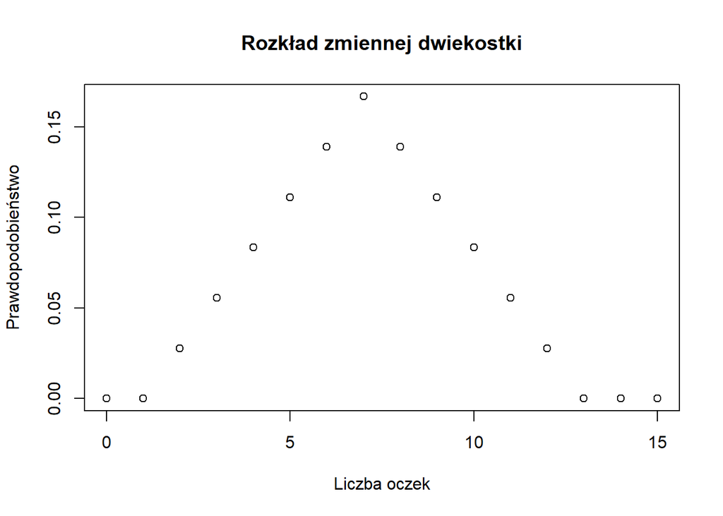

```r
dwiekostki <- DiscreteDistribution(supp = c(2:12), prob = c(1/36, 2/36, 3/36, 4/36, 5/36, 6/36, 5/36, 4/36, 3/36, 2/36, 1/36), ) # definicja nowego rozkladu

ddwiekostki <- d(dwiekostki)  # gęstość
pdwiekostki <- p(dwiekostki)  # dystrybuanta
qdwiekostki <- q(dwiekostki)  # funkcja kwantylowa
rdwiekostki <- r(dwiekostki)  # generowanie liczb losowych

plot(0:15, ddwiekostki(x = 0:15), main = "Rozkład zmiennej dwiekostki", xlab="Liczba oczek", ylab="Prawdopodobieństwo")
```

```r
paste("P(X = 0) = ", round(ddwiekostki(x = 0), 3)) # zwraca prawdopodobienstwo ze suma oczek wyniesie x
```

```
## [1] "P(X = 0) =  0"
```

```r
paste("P(3 <= X < 5) = ", round(ddwiekostki(3)+ddwiekostki(4), 3))
```

```
## [1] "P(3 <= X < 5) =  0.139"
```

```r
paste("P(X =/= 8) = ", round(1-ddwiekostki(8), 3))
```

```
## [1] "P(X =/= 8) =  0.861"
```

```r
paste("P(X < 9) = ", round(pdwiekostki(8), 3)) # zwraca wartosc dystrybuanty dla danego x
```

```
## [1] "P(X < 9) =  0.722"
```

```r
paste("P(X >= 4) = ", round(1-pdwiekostki(3), 3))
```

```
## [1] "P(X >= 4) =  0.917"
```

```r
Y<-rdwiekostki(1000)
paste("EY = ", EY<-sum(Y)/1000)
```

```
## [1] "EY =  7.145"
```

```r
paste("D^2Y = ", round(D2Y<-sum((Y-EY)^2/1000), 3))
```

```
## [1] "D^2Y =  6.21"
```

**2.3** Rozważmy rozkład Poissona z parametrem λ=2. Z wykorzystaniem funkcji plot(), narysować rozkład tej zmiennej losowej. Porównać go z rozkładem dla kilku innych wartości parametru λ. Obliczyć P(X=0), P(3≤X<5) oraz P(X≠1). Obliczyć P(X<9) oraz P(X≥4). Wygeneruj 1000 obserwacji z tego rozkładu i zapisz je jako zmienną Y. Ile wynosi EY oraz D2Y?

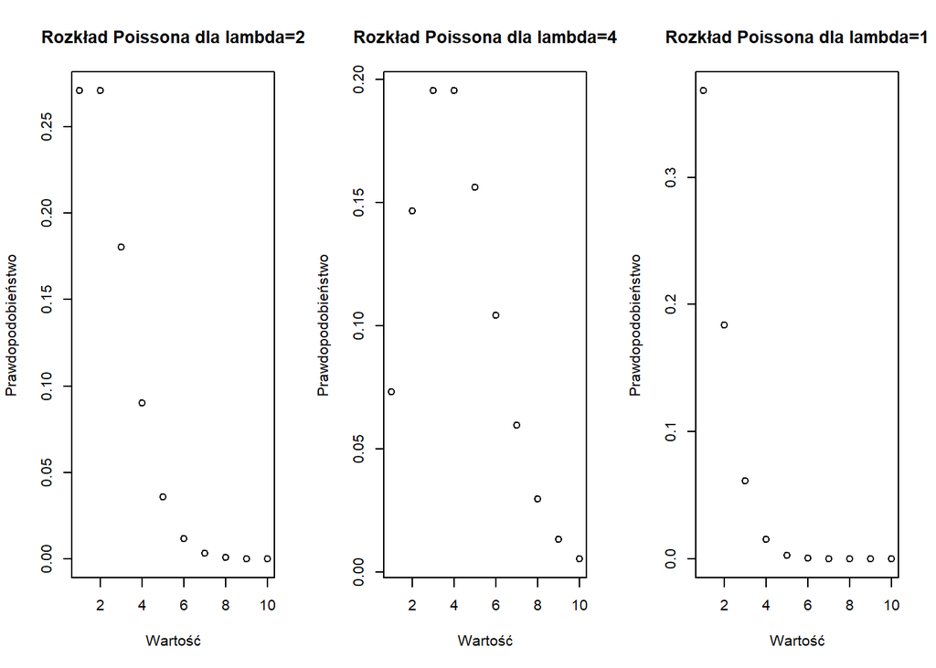

```r
l<-2
n=10
par(mfrow=c(1,3))
plot(x=1:n, y=dpois(1:n, l), main = "Rozkład Poissona dla lambda=2", xlab="Wartość", ylab="Prawdopodobieństwo")  # rpois generuje n liczb z rozkladu Poissona o  danym lambda
plot(x=1:n, y=dpois(1:n, l+2), main = "Rozkład Poissona dla lambda=4", xlab="Wartość", ylab="Prawdopodobieństwo")
plot(x=1:n, y=dpois(1:n, l-1), main = "Rozkład Poissona dla lambda=1", xlab="Wartość", ylab="Prawdopodobieństwo")
```

```r
paste("P(X = 0) = ", round(dpois(0, l), 3)) # dpois zwraca prawdopodobienstwo dla danego k i λ
```

```
## [1] "P(X = 0) =  0.135"
```

```r
paste("P(3 <= X < 5) = ", round(dpois(3, l)+dpois(4, l), 3))
```

```
## [1] "P(3 <= X < 5) =  0.271"
```

```r
paste("P(X =/= 1) = ", round(1-dpois(1, l), 3))
```

```
## [1] "P(X =/= 1) =  0.729"
```

```r
paste("P(X < 9) = ", round(ppois(8, l), 4)) # ppois zwraca wartosc dystrybuany dla danego k i λ
```

```
## [1] "P(X < 9) =  0.9998"
```

```r
paste("P(X >= 4) = ", round(1-ppois(3, l), 3))
```

```
## [1] "P(X >= 4) =  0.143"
```

```r
Y<-rpois(1000, l)
paste("EY = ", EY<-sum(Y)/1000)
```

```
## [1] "EY =  2.047"
```

```r
paste("D^2Y = ", round(D2Y<-sum((Y-EY)^2/1000), 3))
```

```
## [1] "D^2Y =  2.081"
```

**3.1** Zajmijmy się rozkładem zmiennej losowej Xn, której wartość jest równa liczbie otrzymanych orłó w n rzutach monetą. Mamy zatem do czynienia ze zmienną z rozkładu dwumianowego: Xn∼B(n,p) w którym =0.5.

Wyznacz rozkłady zmiennych Xn przyjmując kolejno n=10,n=100,n=1000,n=10000. Sporządź wykresy rozkładów masy prawdopodobieństwa tych zmiennych. Korzystając z funkcji par() i ustawiając odpowiednio argumenty mfrow, mfcol spraw, by wykresy pojawiły się na czterech osobnych rysunkach tworzących macierz 2x 2 (tzn. dwa rysunki obok siebie, dwa kolejne poniżej).

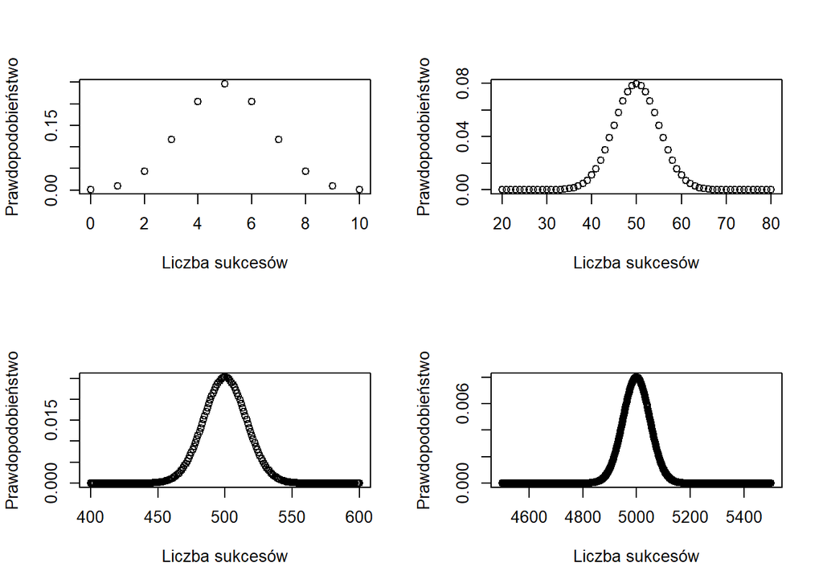

```r
p<-0.5
q<-1-p
n1<-10
n2<-100
n3<-1000
n4<-10000

par(mfrow=c(2,2))
plot(x=0:10, y = dbinom(0:10,  n1, p),  ylab="Prawdopodobieństwo", xlab="Liczba sukcesów" )
plot(x=20:80, y = dbinom(20:80,  n2, p),  ylab="Prawdopodobieństwo", xlab="Liczba sukcesów")
plot(x=400:600, y = dbinom(400:600,  n3, p),  ylab="Prawdopodobieństwo", xlab="Liczba sukcesów")
plot(x=4500:5500, y = dbinom(4500:5500,  n4, p),  ylab="Prawdopodobieństwo", xlab="Liczba sukcesów")
```

Wyznacz rozkłady zestadaryzowanych zmiennych Zn przyjmując kolejno n=10,n=100,n=1000,n=10000. Sporządź wykresy dystrybuant tych zmiennych losowych, a także wykres dystrybuanty standardowego rozkładu normalnego. Podobnie jak w punkcie a) narysuj te wykresy obok siebie. Czy widzisz jakąś zależność?

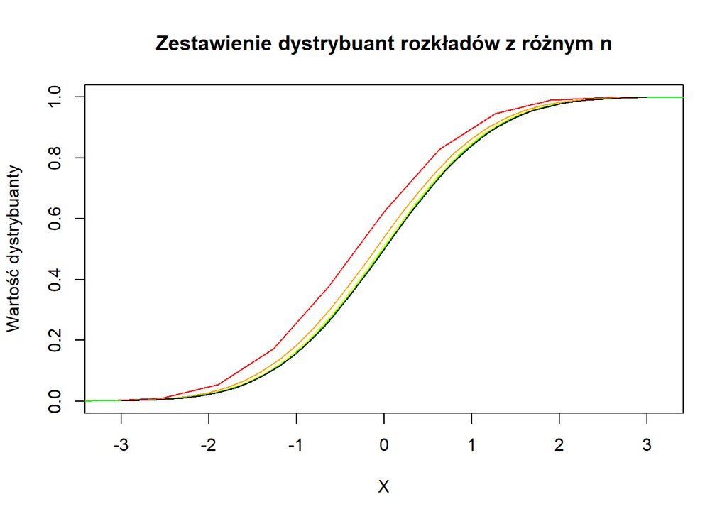

```r
Z10 <- (0:n1-n1*p)/sqrt(n1*p*q)
Z100 <- (0:n2-n2*p)/sqrt(n2*p*q)
Z1000 <- (0:n3-n3*p)/sqrt(n3*p*q)
Z10000 <- (0:n4-n4*p)/sqrt(n4*p*q)


plot(Z10, pbinom(0:n1, n1, p), type='l', col='red', xlab="X", ylab="Wartość dystrybuanty", main="Zestawienie dystrybuant rozkładów z różnym n")
lines(Z100, pbinom(0:n2, n2, p), col='orange')
lines(Z1000, pbinom(0:n3, n3, p), col='yellow')
lines(Z10000, pbinom(0:n4, n4, p), col='green')
lines(seq(-3, 3, 0.1), pnorm(seq(-3, 3, 0.1), 0, 1), col="black")
```

Im większa jest próba, tym dystrubanta standaryzowanej zmiennej losowej jest dokładniej przybliżona dystrybuantą rozkładu normalnego standardowego.

Niech Xn będzie zmienną losową z rozkładu Bernoulliego B(n,p) gdzie p=0.3, a Yn zmienną losową o rozkładzie normalnym N(np,npq−−−√). Na wspólnym rysunku zamieść wykres masy prawdopodobieństwa zmiennej losowej Xn oraz wykres gęstości zmiennej Yn przyjmując kolejno n=10,1000,1000. Jaką zależność dostrzegasz?

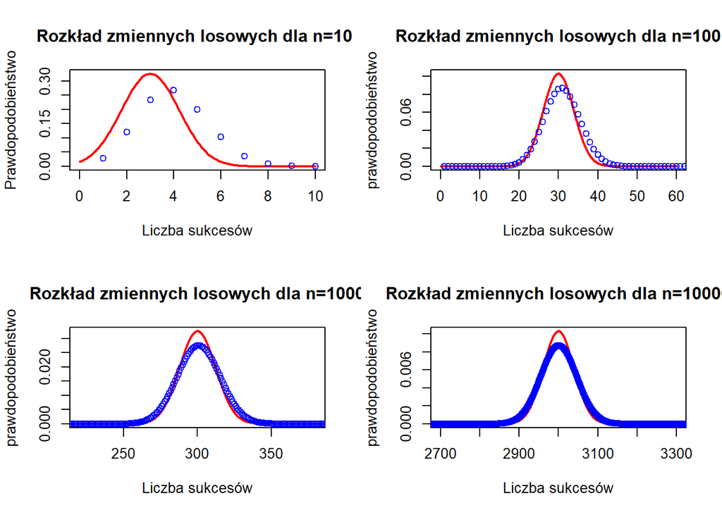

```r
p<-0.3

par(mfrow=c(2,2))
plot( x = seq(0, n1, 0.1), y = dnorm(seq(0, n1, 0.1), mean = n1*p , sd = sqrt(n1*p*q)), xlab = "Liczba sukcesów", ylab = "Prawdopodobieństwo", main = "Rozkład zmiennych losowych dla n=10 ", type='l', col='red', lwd=2)
points(x = dbinom(x = 0:n1 , n1, p), col = 'blue')

plot( x = seq(0, 60, 0.1), y = dnorm(seq(0, 60, 0.1), mean = n2*p , sd = sqrt(n2*p*q)), xlab = "Liczba sukcesów", ylab = "prawdopodobieństwo", main = "Rozkład zmiennych losowych dla n=100", type='l', col='red', lwd=2)
points(x = dbinom(x = 0:n2 , n2, p), col = 'blue')

plot( x = seq(220, 380, 0.1), y = dnorm(seq(220, 380, 0.1), mean = n3*p , sd = sqrt(n3*p*q)), xlab = "Liczba sukcesów", ylab = "prawdopodobieństwo", main = "Rozkład zmiennych losowych dla n=1000", type='l', col='red', lwd=2)
points(x = dbinom(x = 0:n3 , n3, p), col = 'blue')

plot( x = seq(2700, 3300, 0.1), y = dnorm(seq(2700, 3300, 0.1), mean = n4*p , sd = sqrt(n4*p*q)), xlab = "Liczba sukcesów", ylab = "prawdopodobieństwo", main = "Rozkład zmiennych losowych dla n=10000", type='l', col='red', lwd=2)
points(x = dbinom(x = 0:n4 , n4, p), col = 'blue')
```

Można zauważyć, że dla dużych n dystrybuanty są do siebie podobne. Widać tutaj wnioski z twierdzenia de Moivre’a-Laplace’a, z którego wynika, że Im większe jest n, tym rozkład zmiennej zestandaryzowanej, jest lepiej przybliżony przez rozkład normalny standardowy.

**3/Problem 1** Rozkład codziennego dojazdu do pracy jest rozkładem jednostajnym na przedziale [0,5h;1h] i czasy dojazdu w różne dni są niezależne. Jakie jest prawdopodobieństwo tego, że średni dojazd w ciągu 40 dni przekroczy 48 min.? Oblicz to prawdopodobieństwo wykorzystując odpowiednie CTG. Oszacuj je wykorzystując symulację Monte Carlo.

Wykorzystując CTG

```r
n=40  # zmienna ma rozkład ~N(m, s/sqrt(n))
m<-(60+30)/2
s=sqrt((60-30)^2/12)
#P(X>48) ->P(U>2,19), U~N(0, 1)
paste("Prawdopodobieństwo, że w ciągu 40 dni średni czas dojazdu przekroczy 48min wynosi: ", round(1 - pnorm(48, m , s/sqrt(40)), 4))
```

```
## [1] "Prawdopodobieństwo, że w ciągu 40 dni średni czas dojazdu przekroczy 48min wynosi:  0.0142"
```

Metodą Monte Carlo

```r
s = 0
for(i in 1:100000)
{
  wyniki <- c()
  wyniki <- sample(x = 30:60, size = 40,replace = TRUE)
  if(mean(wyniki)>48)
  {
    s = s + 1
  }
}
paste("Prawdopodobieństwo, że w ciągu 40 dni średni czas dojazdu przekroczy 48min wynosi: ", s/100000)
```

```
## [1] "Prawdopodobieństwo, że w ciągu 40 dni średni czas dojazdu przekroczy 48min wynosi:  0.01694"
```

Wynik otrzymany z symulacji Monte Carlo jest podobny do tego uzyskanego za pomocą CTG, choć różni się nieco, zapewne z tego, że choć n=40 jest spore, to przybliżenie dla takiej wartości nie jest idealne, dla większych wartości byłoby lepsze.

**4.1** Wiadomo, że średnia arytmetyczna jest zgodnym estymatorem wartości oczekiwanej E(X), tzn. wraz ze zwiększaniem badanej próby maleje prawdopodobieństwo popełnienia dużego błędu oceny szacowanego parametru rozkładu. Postaraj się zobrazować tę własność estymatora, przyjmując, że X ma rozkład normalny N(3,1). W tym celu wygeneruj n elementową próbę z tego rozkładu i na jej podstwie wyznacz estymator zgodny wartości oczekiwanej przyjmując kolejno n=1, n=5, n=10, n=50, n=100. Na wspólnym wykresie przedstaw gęstości rozkładów N(X¯¯¯¯n,1) oraz rzeczywistą gęstość rozkładu zmiennej losowej X. Sformułuj wnioski.

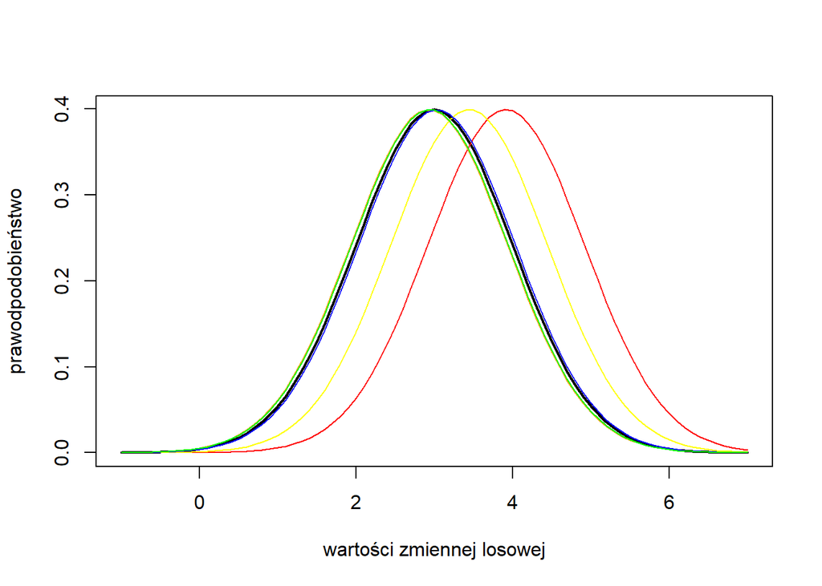

```r
X1<-rnorm(1, 3, 1)
X5<-rnorm(5, 3, 1)
X10<-rnorm(10, 3, 1)
X50<-rnorm(50, 3, 1)
X100<-rnorm(100, 3, 1)

X5=sum(X5)/5
X10=sum(X10)/10
X50=sum(X50)/50
X100=sum(X100)/100

p=seq(-1, 7, 0.1)

plot(p, dnorm(p, 3, 1), type="l", col="black", lwd=2, xlab="wartości zmiennej losowej", ylab="prawodpodobieństwo")
lines(p, dnorm(p, X1, 1), col='red')
lines(p, dnorm(p, X5, 1), col='orange')
lines(p, dnorm(p, X10, 1), col='yellow')
lines(p, dnorm(p, X50, 1), col='blue')
lines(p, dnorm(p, X100, 1), col='green')
```

Estymator jest tym dokładniejszy, im większe mamy n - średnia z 1 czy 5 wylosowanych wartości rozkładu może odbiegać od jego wartości oczekiwanej dość wyraźnie, natomiast dla 50 czy 100 liczb, średnia ta jest zbliżona do EX, co widać na wykresie gęstości - gęstości rozkładów dla większych n są bliżej orginalnego rozkładu od tych dla małych n.

Te same polecenia wykonaj przyjmując, że X ma rozkład t5

```r
d_f=5
T1<-rt(1, d_f)
T5<-rt(5, d_f)
T10<-rt(10, d_f)
T50<-rt(50, d_f)
T100<-rt(100, d_f)


paste("Wartość estymatora dla n = 1: ", sum(T1)/1)
```

```
## [1] "Wartość estymatora dla n = 1:  1.89386161903"
```

```r
paste("Wartość estymatora dla n = 5: ", sum(T5)/5)
```

```
## [1] "Wartość estymatora dla n = 5:  -0.0112904717386981"
```

```r
paste("Wartość estymatora dla n = 10: ", sum(T10)/10)
```

```
## [1] "Wartość estymatora dla n = 10:  -0.391042836232023"
```

```r
paste("Wartość estymatora dla n = 50: ", sum(T50)/50)
```

```
## [1] "Wartość estymatora dla n = 50:  0.177873733375943"
```

```r
paste("Wartość estymatora dla n = 100: ", sum(T100)/100)
```

```
## [1] "Wartość estymatora dla n = 100:  0.0388828311389285"
```

Wartość oczekiwana rozkładu każdego rozkładu t-Studenta wynosi 0, a więc wartości estymatorów też powinny dążyć do tej wartości. Widać, że im większe n, tym estymator dąży bardziej do 0 (a właściwie ma na to większe prawdopodbieństwo, nie za każdym razem otrzyma się takie wyniki)

**4.2** Wiadomo, że “dobrym” estymatorem nieznanej wariancji zmiennej losowej X jest wariancja z próby, którą możemy obliczyć na dwa sposoby: s^2=1/n * ∑=(xi−x)^2 s^2=1/n−1 * ∑=(xi−x)^2 Zbadaj własności tych estymatorów przyjmując, że X ma rozkład Poissona z parametrem λ=5. W tym celu napisz funkcje, które dla n elementowej próby z rozkładu P(5) zwracają wartości powyższych statystyk. Na wspólnym wykresie przedstaw wartości tych funkcji uzyskane na podstawie tej samej n elementowej próby kolejno dla n=1,2,3,…1000. Umieść na nim także funkcję stale równą prawdziwej wartości wariancji w rozważanym rozkładzie. Sformułuj wnioski.

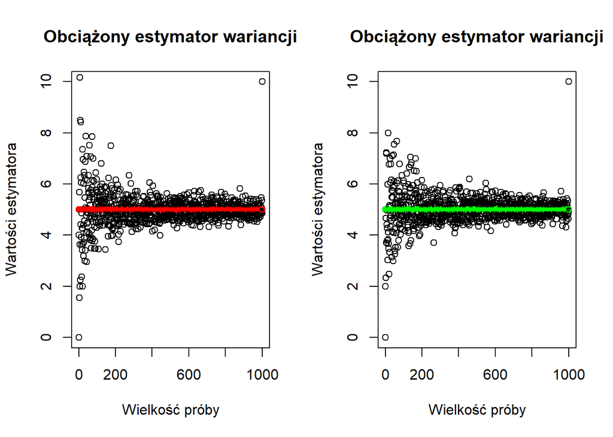

```r
x<-1:1000
S1<-function(x) # estymator obciążony wariancji
{
  s<-0
  for(i in 1:length(x))
  {
    s = s+(x[i]-mean(x))^2
  }
  return(s/length(x))
}

S2<-function(x) # estymator nieobiciążony wariancj
{  i
  s<-0
  for( i in 1:length(x))
  {
    s = s+(x[i]-mean(x))^2
  }
  return(s/(length(x)-1))
}

par(mfrow =c(1, 2))
l<-5
n <- 1000
plot(c(0,10)~c(1,n), main="Obciążony estymator wariancji", xlab ="Wielkość próby", ylab="Wartości estymatora")
for(i in 1:1000)
{
  y <- rpois(1:i, lambda = l)
  points(i, S1(y) )
  points(i, l, col = "red", lwd="1")
}
plot(c(0,10)~c(1,n), main="Obciążony estymator wariancji", xlab ="Wielkość próby", ylab="Wartości estymatora")
for(i in 1:1000)
{
  y <- rpois(1:i, lambda = l)
  points(i, S2(y) )
  points(i, l, col = "green", lwd="1")
}
```

Na wykresie punkty oznaczją wariancje dla kolejnych wielkości prób, natomiast kolorem oznaczone są wartości lambda, czyli w przypadku rozkładu Poissona zarówno wartość oczekiwana jak i wariancja. Z wykresów widać, że wraz ze wzrostem rozmiaru próby, esymowane wartości wariancji dążą do jej prawdziwej wartości.

Te same polecenia wykonaj przyjmując, że X ma rozkład wykładniczy EXP(2).

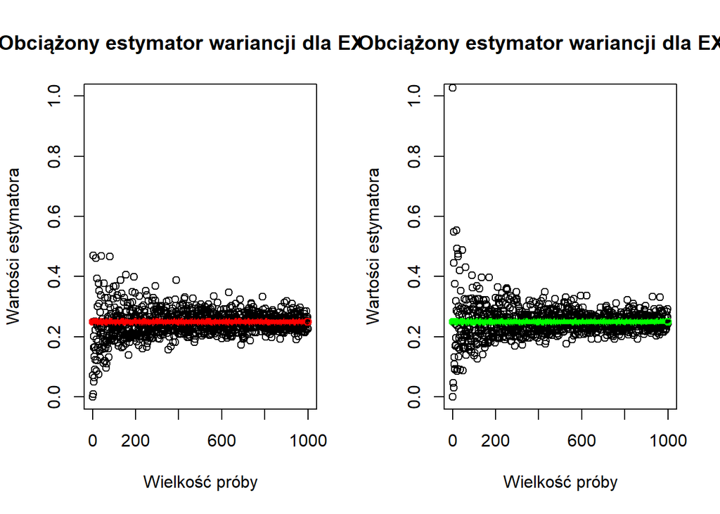

```r
par(mfrow =c(1, 2))
r=2
n <- 1000
plot(c(0,10)~c(1,n), ylim=c(0,1), main="Obciążony estymator wariancji dla EXP(2)", xlab ="Wielkość próby", ylab="Wartości estymatora")
for(i in 1:1000)
{
  y <- rexp(n = 1:i, rate = r)
  points(i, S1(y) )
  points(i, 1/r^2, col = "red", lwd="1")
}
plot(c(0,10)~c(1,n), ylim=c(0,1), main="Obciążony estymator wariancji dla EXP(2)", xlab ="Wielkość próby", ylab="Wartości estymatora")
for(i in 1:1000)
{
  y <- rexp(n = 1:i, rate = r)
  points(i, S2(y) )
  points(i, 1/r^2, col = "green", lwd="1")
}
```

W rozkładzie wykładniczym, wariancja jest równa 1/r^2, w tym przypadku 0.25, co widać na wykresie. Tutaj również widać tę zasadę co w poprzednim przykładzie - wielkość próby rośnie - różnice między estymatorem, a rzeczywistą wariancją stają się średnio coraz mniejsze

**5.1** Przeanalizuj poniższy kod. Zastanów się, jaki test statystyczny przeprowadzono poniżej. Jaka jest hipoteza zerowa i alternatywna.

```r
set.seed(4)
proba <- rnorm(20,mean = 0, sd = 1)
(test <- t.test(proba, alternative = "two.sided"))
```

```
##
##  One Sample t-test
##
## data:  proba
## t = 2.1001, df = 19, p-value = 0.0493
## alternative hypothesis: true mean is not equal to 0
## 95 percent confidence interval:
##  0.001275971 0.751316587
## sample estimates:
## mean of x
## 0.3762963
```

```r
test$p.value
```

```
## [1] 0.0493002
```

```r
test$statistic
```

```
##        t
## 2.100145
```

p-value jest mniejsze od przyjętego alfa, więc hipoteze h0 odrzucamy, więc stwierdzamy, że średnia z próby różni się istotnie od 0. Wartość p-value minimalnie mniejsza od przyjętego alfa=0,05 pokrywa się z tym, że otrzymana wartość statystyki jest minimalnie większa, od wartości t dla 19 stopni swobody i alfa =0,05, więc nasze t minimalnie mieści się w obszarze krytycznym, więc co zostało już wspomniane, h0 odrzucamy. Wynik nieco mnie dziwi (szczególnie mając zrobione zadanie 4.2), głównie dlatego że próba jest dość spora, a odchylenie dośc niewielkie, dlatego spodziewałbym się, że obliczona średnia nie będzie odbiegać znacząco od 0, a co za tym idzie, h0 nie zostałaby odrzucona.

```r
set.seed(4)
proba <- rnorm(20,mean = 0, sd = 1)
(test <- t.test(proba, alternative = "greater"))
```

```
##
##  One Sample t-test
##
## data:  proba
## t = 2.1001, df = 19, p-value = 0.02465
## alternative hypothesis: true mean is greater than 0
## 95 percent confidence interval:
##  0.06647666        Inf
## sample estimates:
## mean of x
## 0.3762963
```

```r
test$p.value
```

```
## [1] 0.0246501
```

```r
test$statistic
```

```
##        t
## 2.100145
```

Zmieniając hipotezę alternatywną z różne na większe, nie zmienia się wartość statystyki, ale zmienia się obszar krytyczny, chodź w tym przypadku wiele to nie zmienia, bo p<alfa, więc odrzucamy hipotezę h0 i stwierdzamy, że średnia jest isttotnie większa od 0. Skoro wcześniej już przyjeliśmy hipotezę h1 mówiącą, że średnia różni się od 0, w tym przypadku, h0 zostałoby tym bardziej odrzucone, ponieważ zwiększa się przedział wartości krytycznych (po stronie dodatniej, w porównaniu do poprzedniej wersji), a co za tym idzie t tym bardziej mieści się w tym przedziale, a teraz po prostu ustalamy kierunek wspomnianej istotniej różnicy.

**5.2** Wróćmy do wyjściowej postaci testu i powtórzmy powyższe doświadczenie 10000 razy. Wywołaj poniższy kod:

```r
pv <- stat <- c()

for (i in 1:10000){
  proba <- rnorm(20,mean = 0, sd = 1)
  test = t.test(proba, alternative = "two.sided")
    pv[i] = test$p.value
  stat[i] = test$statistic
}
```

Ile razy test odrzucił hipotezę zerową? Czy ten wynik Cię dziwi? Przypomnij sobie, co to jest błąd pierwszego rodzaju. Jak w tym kontekście skomentujesz wyniki? Spróbuj narysować histogram zmiennej stat. Co oznacza ta zmienna? Jak wygląda jej rozkład? Jak to się ma do teorii?

```r
table(pv>0.05)
```

```
##
## FALSE  TRUE
##   515  9485
```

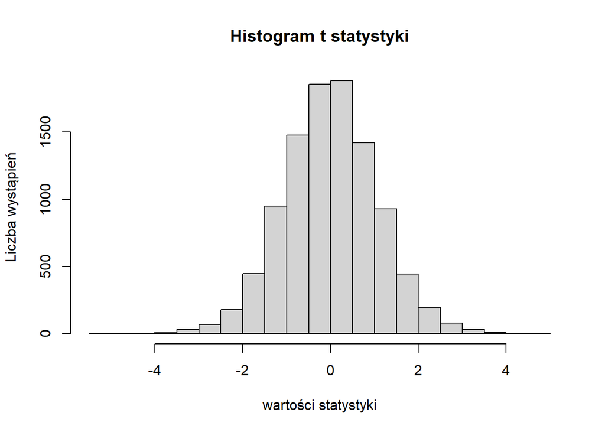

```r
hist(stat, main = "Histogram t statystyki", xlab="wartości statystyki", ylab="Liczba wystąpień")
```

W ciągu 10000 testów, hipotezę odrzucono, w przybliżeniu w 5% przypadków, co pokrywa się z przyjętym poziomem istotności alfa 5% Błąd I rodzaju to odrzucenie hipotezy H0, gdy w istocie jest ona prawdziwa. Zmniejszając lub zwiększając alfa, można zmniejszyć lub zwiększyć prawodpodobieństwo popełńienia błędu tego rodzaju. Histogram pokazujący liczność wartości statystyki w konkretnych przedziałach układa się podobnie jak krzywa gęstości rozkładu normalnego o m=0 i sd=1, jest tak ponieważ wartości t po standaryzacji mają standardowy rozkład normalny.